# Suavizamiento exponencial y medias móviles

Series de Tiempo

Bladimir Morales Torrez

Septiembre 2021

# 1 Serie 1. Incidencia en el Producto Interno Bruto (PIB)

## 1.1 Introducción

El Producto Interno Bruto (PIB), es es un indicador que nació en una de las peores etapas que sufrió la economía mundial en 1934. En esta época debido al denominado *CRACK*[^1] de 1929, donde existía una recesión mundial que afectaba a todos los países desarrollados, el economista Simon Kuznets presentó un informe al Congreso de los Estados Unidos cuyo título fue ``Ingreso Nacional 1929-1932’’, en ese informe se desarrollo por primera vez el concepto del PIB, que se presentó como indicador para medir los ingresos de la economía de un país[^2].

## 1.2 Datos

La serie de tiempo a estudiar es la incidencia en el Producto Interno Bruto (PIB) de Bolivia a precios constantes trimestrales, que es calculado a partir del PIB a precios constantes.

El periodo a ser tomado en cuenta es desde el primer trimestre de 1991 hasta el primer trimestre del 2020, teniendo 117 observaciones.

## 1.3 Fuente de datos

Para el caso de Bolivia en la página oficial del Instituto Nacional de Estadística de Bolivia (INE), esta publicada la información referente al PIB en serie histórica con precios constantes y corrientes. En este contexto también se cuenta con los datos de la incidencia en el PIB boliviano desde el año 1991 en el caso trimestral y desde 1980 para el caso anual (https://www.ine.gob.bo/index.php/estadisticas-economicas/pib-y-cuentas-nacionales/producto-interno-bruto-trimestral/producto-interno-bruto-trimestral-intro/#1604584724125-615aec14-e917).

## 1.4 Gráfico de la serie

En el siguiente gráfico se muestra la serie de tiempo de la incidencia del PIB boliviano en los periodos comprendidos desde el primer trimestre de 1991 hasta el primer trimestre del 2020, teniendo en total 117 observaciones.

```r
url<-"https://raw.githubusercontent.com/bladimir-morales/series_de_tiempo/main/data/incidencia_pib_trim_91_20.txt"
pib<-read.table(url,head=T)

#Serie de tiempo
serie_pib<-ts(pib,start = c(1991,1),frequency = 4)
```

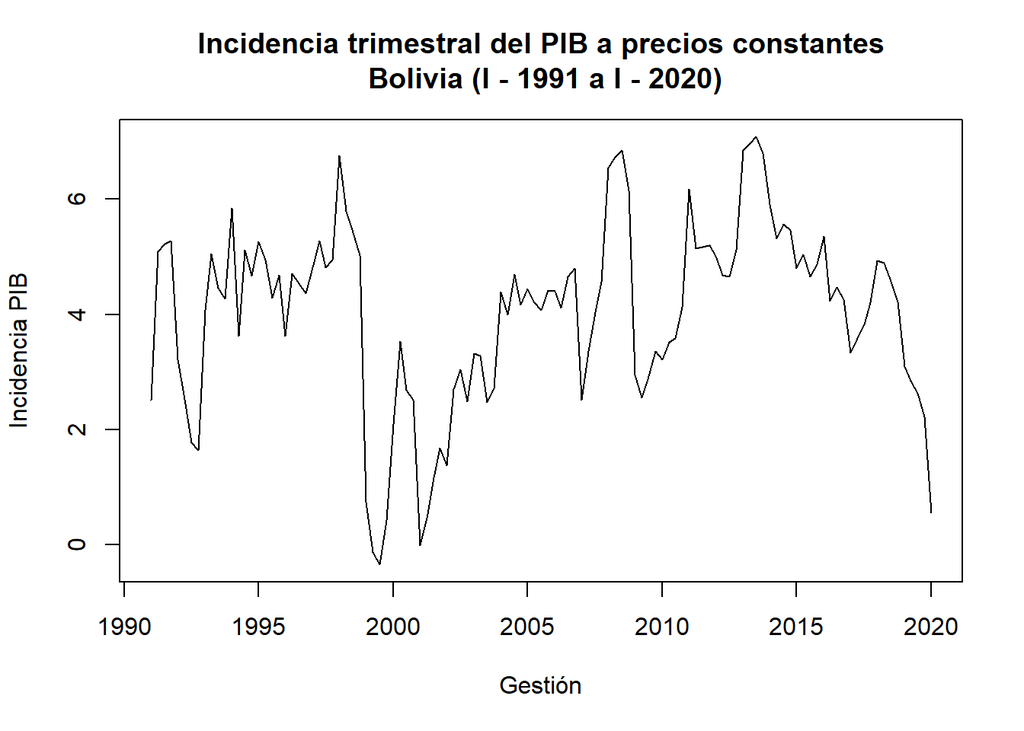

```r
plot(serie_pib,main="Incidencia trimestral del PIB a precios constantes\n Bolivia (I - 1991 a I - 2020)",
     xlab="Gestión",ylab="Incidencia PIB")
```

Esta serie de tiempo al hacer un análisis visual presumiblemente tendrá el siguiente comportamiento:

- Media constante.
- Varianza constante.

Obs. No cuenta con tendencia, estacionalidad y comportamiento ciclico.

## 1.5 Datos de entrenamiento y de test

La serie para efectos de práctica se dividirá en dos:

- Datos de entrenamiento que estarán comprendidos en los periodos de:
  - Primer trimestre de 1991 a cuarto trimestre de 2018. (112 datos).

```r
serie_pib_ent<-ts(pib[1:112,],start = c(1991,1),frequency = 4)
serie_pib_ent
```

```
##       Qtr1  Qtr2  Qtr3  Qtr4
## 1991  2.51  5.09  5.22  5.27
## 1992  3.21  2.53  1.78  1.65
## 1993  4.08  5.05  4.46  4.27
## 1994  5.85  3.63  5.12  4.67
## 1995  5.26  4.95  4.28  4.68
## 1996  3.63  4.71  4.54  4.36
## 1997  4.81  5.28  4.82  4.95
## 1998  6.75  5.79  5.42  5.03
## 1999  0.74 -0.12 -0.34  0.43
## 2000  2.09  3.53  2.69  2.51
## 2001 -0.01  0.47  1.17  1.68
## 2002  1.38  2.70  3.05  2.49
## 2003  3.32  3.28  2.48  2.71
## 2004  4.39  3.99  4.70  4.17
## 2005  4.45  4.20  4.07  4.42
## 2006  4.41  4.12  4.66  4.80
## 2007  2.52  3.36  4.03  4.56
## 2008  6.55  6.73  6.85  6.15
## 2009  2.95  2.55  2.92  3.36
## 2010  3.22  3.52  3.59  4.13
## 2011  6.18  5.15  5.17  5.20
## 2012  5.01  4.68  4.65  5.12
## 2013  6.85  6.97  7.08  6.80
## 2014  5.91  5.32  5.56  5.46
## 2015  4.80  5.04  4.66  4.86
## 2016  5.35  4.23  4.47  4.26
## 2017  3.34  3.58  3.82  4.20
## 2018  4.93  4.89  4.57  4.22
```

- Datos de test que estarán comprendidos en los periodos de:
  - Primer trimestre de 2019 a primer trimestre de 2020. (5 datos).

```r
serie_pib_test<-ts(pib[113:117,],start = c(2019,1),frequency = 4)
serie_pib_test
```

```
##      Qtr1 Qtr2 Qtr3 Qtr4
## 2019 3.09 2.85 2.64 2.22
## 2020 0.56
```

## 1.6 Estimación

### 1.6.1 Suavizamiento exponencial simple

**Modelo**

```r
mod1_serie_pib<-HoltWinters(serie_pib_ent,beta=FALSE,gamma = FALSE)
mod1_serie_pib
```

```
## Holt-Winters exponential smoothing without trend and without seasonal component.
##
## Call:
## HoltWinters(x = serie_pib_ent, beta = FALSE, gamma = FALSE)
##
## Smoothing parameters:
##  alpha: 0.9999339
##  beta : FALSE
##  gamma: FALSE
##
## Coefficients:
##       [,1]
## a 4.220023
```

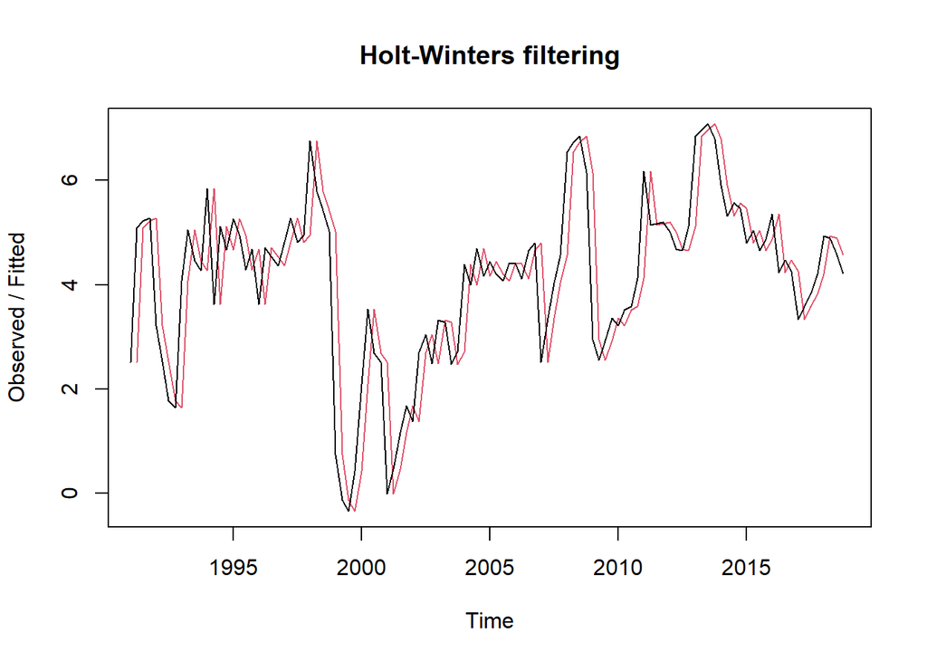

```r
plot(mod1_serie_pib)
```

**Medida de calidad de ajuste**

```r
PE<-abs((mod1_serie_pib$x-mod1_serie_pib$fitted)/mod1_serie_pib$x)
MAPE<-sum(PE)/length(PE)
MAPE*100
```

```
## [1] 258.1725
```

**Predicción**

```r
mod1_serie_pib_pred<-forecast(mod1_serie_pib,h=5)
mod1_serie_pib_pred
```

```
##         Point Forecast    Lo 80    Hi 80      Lo 95    Hi 95
## 2019 Q1       4.220023 2.911836 5.528211  2.2193230 6.220723
## 2019 Q2       4.220023 2.370028 6.070018  1.3906994 7.049347
## 2019 Q3       4.220023 1.954276 6.485770  0.7548616 7.685185
## 2019 Q4       4.220023 1.603778 6.836268  0.2188213 8.221225
## 2020 Q1       4.220023 1.294982 7.145065 -0.2534417 8.693488
```

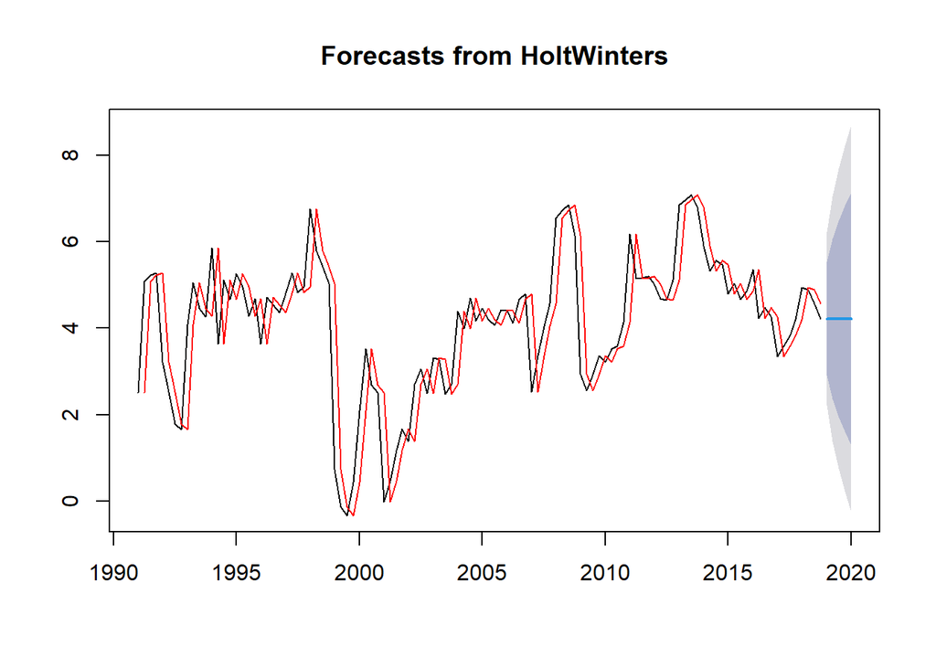

```r
plot(mod1_serie_pib_pred)
lines(mod1_serie_pib_pred$fitted,col="red")
```

**Análisis de residuos**

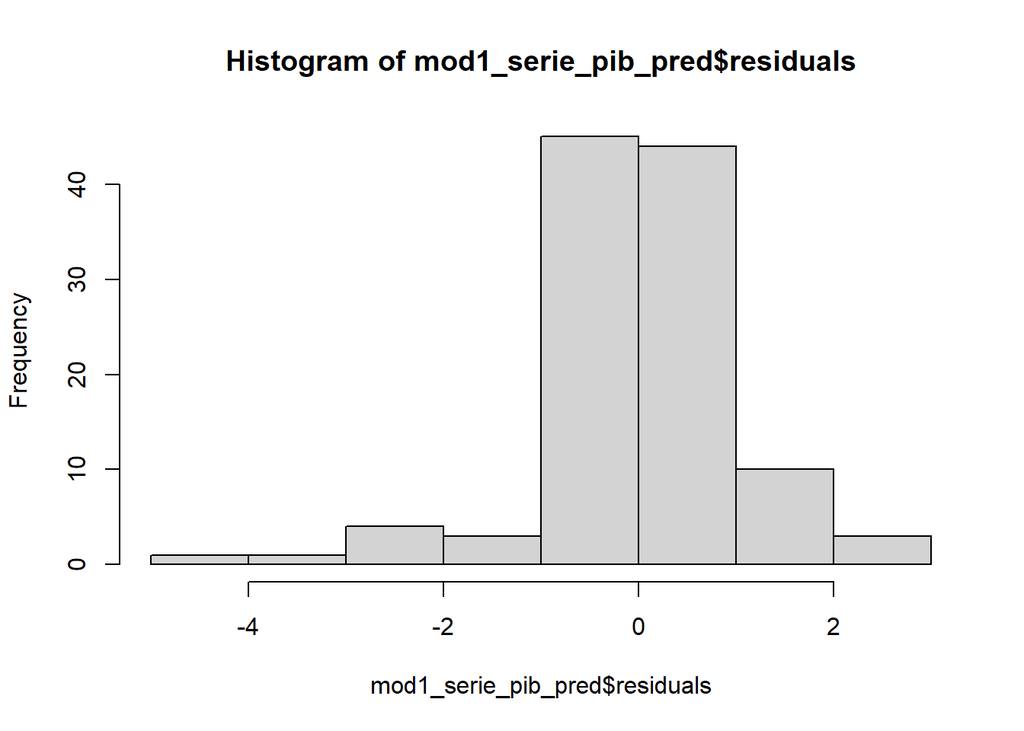

```r
hist(mod1_serie_pib_pred$residuals)
```

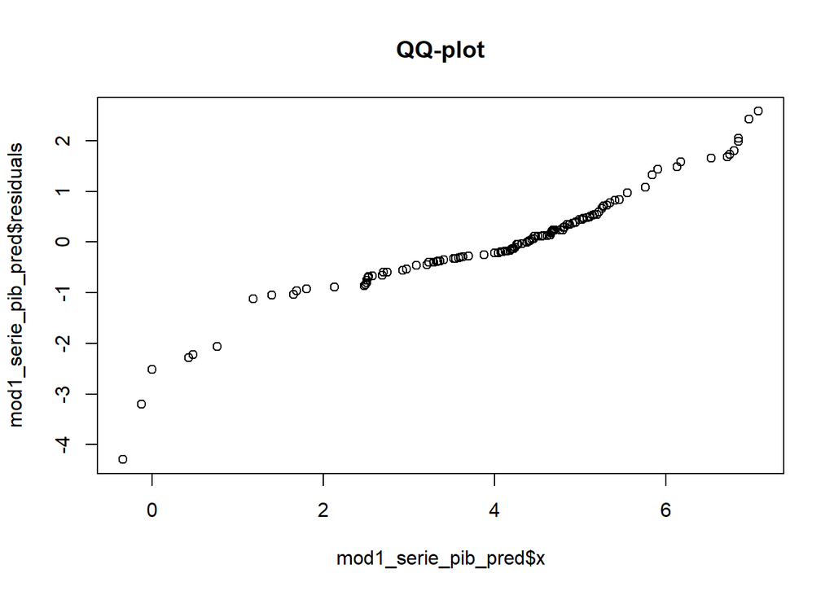

```r
qqplot(mod1_serie_pib_pred$x,mod1_serie_pib_pred$residuals,main="QQ-plot")
```

# 2 Serie 2. Indice mensual de consumo de agua potable

## 2.1 Introducción

El indice de consumo de agua potable, es un indicador que nos permite conocer la evolución y comportamiento del consumo de agua potable de los sectores privado y público.

## 2.2 Datos

El periodo a ser tomado en cuenta es desde enero de 1990 hasta julio del 2021, teniendo 379 observaciones en total. Este indicador se establece con un año base que en este caso es 1990 en el cual se iguala el consumo de agua potable a 100, a partir de este registro se calcula el aumento o decremento posterior al año base.

## 2.3 Fuente de datos

Para el caso de Bolivia en la página oficial del Instituto Nacional de Estadística de Bolivia (INE)[^3], esta publicada la información referente al indice mensual de consumo de servicios básicos por tipo de servicio en serie histórica según año y mes. En este contexto se cuenta con los datos del consumo de agua potable desde enero de 1990 hasta julio del 2021 (https://www.ine.gob.bo/index.php/estadisticas-economicas/servicios-basicos-cuadros-estadisticos/).

Los metadatos están disponibles en el Catálogo del Archivo Nacional de Datos (ANDA) del INE (http://anda4.ine.gob.bo/ANDA4_2/index.php/catalog/254).

## 2.4 Gráfico de la serie

En el siguiente gráfico se muestra la serie de tiempo del indice del consumo de agua potable en Bolivia en los periodos comprendidos desde enero de 1990 hasta julio del 2021, teniendo en total 379 observaciones.

```r
url<-"https://raw.githubusercontent.com/bladimir-morales/series_de_tiempo/main/data/indice_consumo_de agua potable_mes_90_21.txt"
agua<-read.table(url,head=T)

serie_agua<-ts(agua,start = c(1990,1),frequency = 12)
```

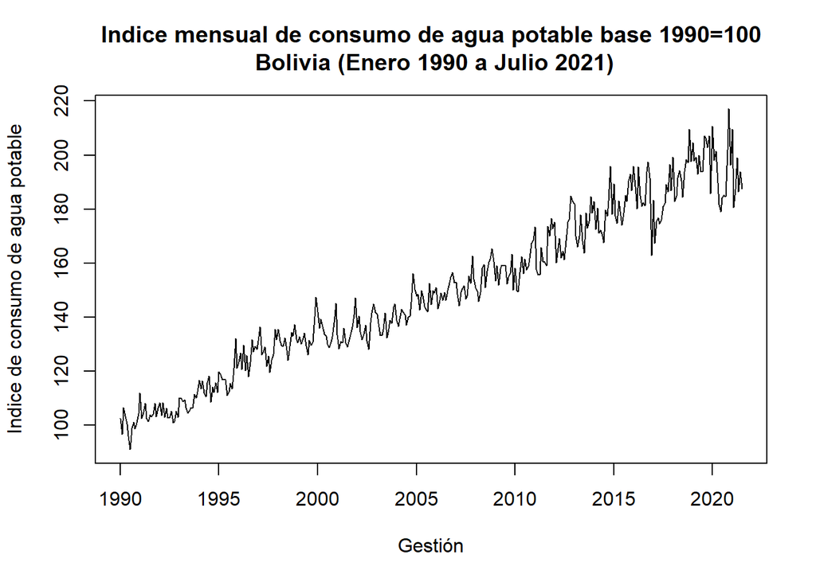

```r
plot(serie_agua,main="Indice mensual de consumo de agua potable base 1990=100\n Bolivia (Enero 1990 a Julio 2021)",
     xlab="Gestión",ylab="Indice de consumo de agua potable")
```

Obs. No cuenta con estacionalidad y comportamiento cíclico.

## 2.5 Datos de entrenamiento y de test

La serie para efectos de práctica se dividirá en dos:

- Datos de entrenamiento que estarán comprendidos en los periodos de:
  - Enero de 1990 a diciembre de 2020. (372 datos).

```r
serie_agua_ent<-ts(agua[1:372,],start = c(1990,1),frequency = 12)
serie_agua_ent
```

```
##         Jan    Feb    Mar    Apr    May    Jun    Jul    Aug    Sep    Oct
## 1990 102.45  96.72 106.45 103.26 100.50  96.01  90.98  98.82 101.21  98.59
## 1991 111.86 102.52 104.61 108.02 102.51 101.36 103.92 103.21 104.07 108.01
## 1992 108.33 103.65 108.21 102.86 106.30 102.79 102.73 105.10 100.81 101.44
## 1993 110.07 109.82 108.84 109.53 106.55 104.40 105.35 106.54 106.24 111.50
## 1994 116.61 113.54 116.43 111.90 110.63 115.68 118.20 108.52 114.21 112.23
## 1995 119.75 118.80 116.75 116.82 116.85 110.90 112.42 115.41 113.53 121.01
## 1996 123.28 126.67 120.68 129.69 120.28 125.80 117.95 123.45 131.59 127.12
## 1997 131.31 136.46 126.10 127.72 128.90 121.74 125.62 119.63 124.01 126.35
## 1998 135.57 131.19 129.68 129.26 132.39 127.75 124.13 129.24 134.37 133.07
## 1999 130.55 132.70 130.13 132.10 134.21 129.44 125.97 131.37 129.54 130.80
## 2000 141.91 135.84 139.20 136.54 133.59 133.11 130.01 128.77 130.78 132.75
## 2001 133.48 128.27 130.89 130.48 135.99 130.60 128.90 130.78 133.39 136.45
## 2002 136.12 140.34 134.64 131.73 133.72 137.14 131.22 128.00 137.98 141.44
## 2003 141.13 137.63 133.23 133.21 135.55 141.58 132.22 134.39 138.73 137.62
```

[output cut: 49 more lines]

- Datos de test que estarán comprendidos en los periodos de:
  - Enero de 2021 a julio de 2021. (7 datos).

```r
serie_agua_test<-ts(agua[373:379,],start = c(2021,1),frequency = 12)
serie_agua_test
```

```
##         Jan    Feb    Mar    Apr    May    Jun    Jul
## 2021 209.44 180.62 187.32 199.10 186.50 193.89 187.60
```

# 3 Serie 3. Indice Global de Actividad Económica IGAE

## 3.1 Introducción

El IGAE tiene como objetivo estimar la evolución temporal del ritmo de crecimiento mensual de la actividad económica nacional en el inmediato plazo, con la finalidad de facilitar la toma de decisiones en el diseño y monitoreo de las Políticas Económicas de corto plazo.

El IGAE al ser una estimación del comportamiento sobre la evolución del PIB trimestral mediante indicadores de referencia y métodos de desagregación temporal, el tratamiento aplicado a cada actividad difiere según las características de la serie de referencia de cada actividad, así como también por la disponibilidad de fuentes de información.

## 3.2 Datos

El IGAE se constituye en un indicador próximo a la evolución temporal del valor agregado, a partir de series de referencia disponibles mensualmente.

Para que la estimación mensual no se desvié de la evolución temporal del PIB trimestral (Valor Agregado Bruto), las series mensuales por actividad económica son ajustadas a las series trimestrales del PIB, utilizando la técnica de los métodos de desagregación temporal.

En concreto en todas las series ajustadas al PIB trimestral se utiliza el método de desagregación temporal de Denton y de Fernandez.

El IGAE es un indicador que aplica la fórmula matemática del Índice de Laspeyres, con ponderaciones fijas del año base 1990 para la agregación de los índices por actividad económica, próximos a la evolución del PIB, las mismas que consideran el periodo base de las Cuentas Nacionales de Bolivia. Toda la metodología puede ser encontrada en el siguiente enlace (https://www.ine.gob.bo/index.php/descarga/407/igae/46158/metodologia-de-cuentas-nacionales-indice-global-de-la-actividad-economica-1990.pdf)

El periodo a ser tomado en cuenta es desde enero del 2008 a julio 2021, teniendo 163 observaciones.

## 3.3 Fuente de datos

Para el caso de Bolivia en la página oficial del Instituto Nacional de Estadística de Bolivia (INE), esta publicada la información referente al IAGE en serie histórica a partir de enero del 2008 a julio del 2021, esta informacion puede ser descargada en el siguiente enlace (https://www.ine.gob.bo/index.php/estadisticas-economicas/indice-global-de-actividad-economica-igae/#1584545313102-06cf787f-a790).

## 3.4 Gráfico de la serie

```r
url<-"https://raw.githubusercontent.com/bladimir-morales/series_de_tiempo/main/data/igae_mes_08_21.txt"
igae<-read.table(url,head=T)

serie_igae<-ts(igae,start = c(2008,1),frequency = 12)
```

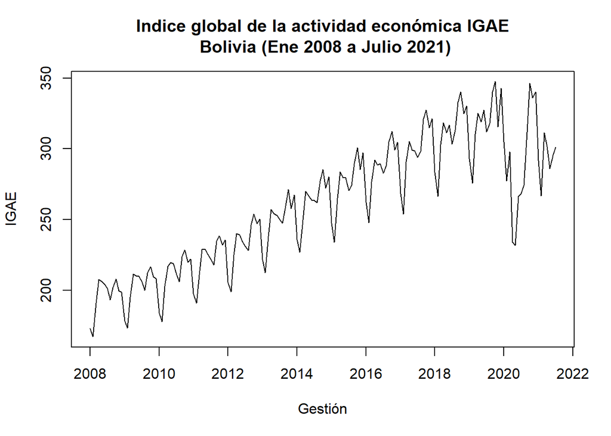

```r
plot(serie_igae,main="Indice global de la actividad económica IGAE\n Bolivia (Ene 2008 a Julio 2021)",
     xlab="Gestión",ylab="IGAE")
```